# Import the dependencies

```python
import numpy as np
import pandas as pd
import seaborn as sns
import matplotlib.pyplot as plt
from sklearn.cluster import DBSCAN
from sklearn.preprocessing import StandardScaler
```

```python
# Importing the data set
# data collection and preprocessing
# Step 1: Load the full dataset
iris_data=pd.read_csv("iris.csv")
iris_data.head()
```

|  | sepal_length | sepal_width | petal_length | petal_width | species |
| --- | --- | --- | --- | --- | --- |
| 0 | 5.1 | 3.5 | 1.4 | 0.2 | setosa |
| 1 | 4.9 | 3.0 | 1.4 | 0.2 | setosa |
| 2 | 4.7 | 3.2 | 1.3 | 0.2 | setosa |
| 3 | 4.6 | 3.1 | 1.5 | 0.2 | setosa |
| 4 | 5.0 | 3.6 | 1.4 | 0.2 | setosa |

## eps

```python
import pandas as pd
import numpy as np
from sklearn.cluster import DBSCAN
from sklearn.preprocessing import StandardScaler
from sklearn.datasets import load_iris
from IPython.display import display

# Load Iris dataset
iris = load_iris()
df = pd.DataFrame(data=iris.data, columns=iris.feature_names)
df['Species'] = iris.target

# Standardize features
scaler = StandardScaler()
X_scaled = scaler.fit_transform(df[iris.feature_names])

# Define 10 different (eps, min_samples) combinations
dbscan_configs = [
    {"eps": 0.4, "min_samples": 3},
    {"eps": 0.5, "min_samples": 3},
    {"eps": 0.6, "min_samples": 3},
    {"eps": 0.7, "min_samples": 3},
    {"eps": 0.8, "min_samples": 3},
    {"eps": 0.5, "min_samples": 4},
    {"eps": 0.6, "min_samples": 4},
    {"eps": 0.7, "min_samples": 4},
    {"eps": 0.8, "min_samples": 4},
    {"eps": 0.9, "min_samples": 4},
]

# Run DBSCAN with each config and show only those with exactly 3 clusters
for i, config in enumerate(dbscan_configs, start=1):
    dbscan = DBSCAN(eps=config["eps"], min_samples=config["min_samples"])
    labels = dbscan.fit_predict(X_scaled)

    # Count clusters (excluding noise if present)
    n_clusters = len(set(labels)) - (1 if -1 in labels else 0)

    if n_clusters != 3:
        print(f"Config {i}: Skipped (Got {n_clusters} clusters with eps={config['eps']}, min_samples={config['min_samples']})")
        continue

    df_temp = df.copy()
    df_temp['Cluster'] = labels

    # Count and percentage matrix
    count_matrix = pd.crosstab(df_temp['Species'], df_temp['Cluster'], margins=True, margins_name='Total')
    total_counts = count_matrix.loc['Total']
    percentage_matrix = count_matrix.div(total_counts).mul(100).round(1)

    # Combined matrix
    combined_matrix = count_matrix.copy().astype(str)
    for col in count_matrix.columns:
        for idx in count_matrix.index:
            count = count_matrix.loc[idx, col]
            percent = percentage_matrix.loc[idx, col]
            combined_matrix.loc[idx, col] = f"{count} ({percent}%)"

    # Display output
    print(f"\n{'='*80}")
    print(f"DBSCAN RESULT {i}: eps={config['eps']}, min_samples={config['min_samples']} — 3 Clusters Found")
    print("(Format: Count (Percentage%))")

    styled_combined = combined_matrix.style.set_caption(
        f"DBSCAN Config {i} - Species-Cluster Distribution"
    ).set_table_styles([
        {'selector': 'caption', 'props': [('font-size', '16px'), ('font-weight', 'bold'), ('text-align', 'center')]},
        {'selector': 'th', 'props': [('text-align', 'center')]},
        {'selector': '.row_heading, .col_heading', 'props': [('font-weight', 'bold')]},
    ])
    display(styled_combined)

    # Save matrices
    count_matrix.to_csv(f"dbscan_config_{i}_counts.csv")
    percentage_matrix.to_csv(f"dbscan_config_{i}_percentages.csv")
```

```
Config 1: Skipped (Got 10 clusters with eps=0.4, min_samples=3)
Config 2: Skipped (Got 7 clusters with eps=0.5, min_samples=3)
Config 3: Skipped (Got 4 clusters with eps=0.6, min_samples=3)
Config 4: Skipped (Got 2 clusters with eps=0.7, min_samples=3)
Config 5: Skipped (Got 2 clusters with eps=0.8, min_samples=3)
Config 6: Skipped (Got 2 clusters with eps=0.5, min_samples=4)

================================================================================
DBSCAN RESULT 7: eps=0.6, min_samples=4 — 3 Clusters Found
(Format: Count (Percentage%))
```

DBSCAN Config 7 - Species-Cluster Distribution

| Cluster Species | -1 | 0 | 1 | 2 | Total |
| --- | --- | --- | --- | --- | --- |
| 0 | 1 (5.3%) | 46 (100.0%) | 3 (100.0%) | 0 (0.0%) | 50 (33.3%) |
| 1 | 7 (36.8%) | 0 (0.0%) | 0 (0.0%) | 43 (52.4%) | 50 (33.3%) |
| 2 | 11 (57.9%) | 0 (0.0%) | 0 (0.0%) | 39 (47.6%) | 50 (33.3%) |
| Total | 19 (100.0%) | 46 (100.0%) | 3 (100.0%) | 82 (100.0%) | 150 (100.0%) |

```
Config 8: Skipped (Got 2 clusters with eps=0.7, min_samples=4)
Config 9: Skipped (Got 2 clusters with eps=0.8, min_samples=4)
Config 10: Skipped (Got 2 clusters with eps=0.9, min_samples=4)
```

# Step 1: Import libraries

```python
import numpy as np
from sklearn.cluster import DBSCAN
import matplotlib.pyplot as plt
```

Step 2: Define the dataset

```python
# Points from the problem
X = np.array([
    [1, 2],   # P1
    [2, 2],   # P2
    [2, 3],   # P3
    [8, 7],   # P4
    [8, 8],   # P5
    [25, 80]  # P6
])
```

# Step 3: Apply DBSCAN

```python
# Set parameters from the problem
db = DBSCAN(eps=1.5, min_samples=2)
db.fit(X)
```

```
DBSCAN(eps=1.5, min_samples=2)
```

# Step 4: View Results

```python
# Print cluster labels (-1 means noise)
labels = db.labels_
print("Cluster labels:", labels)
```

```
Cluster labels: [ 0  0  0  1  1 -1]
```

# Step 5: Visualize the clusters (optional but helpful)

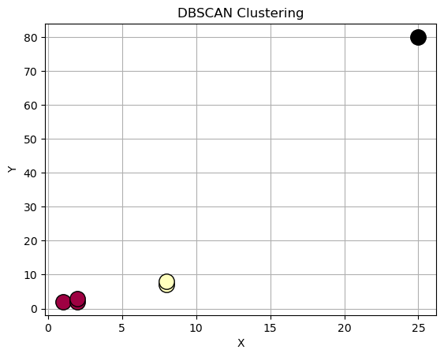

```python
# Assign colors: one for each cluster, black for noise
unique_labels = set(labels)
colors = [plt.cm.Spectral(each) for each in np.linspace(0, 1, len(unique_labels))]

for k, col in zip(unique_labels, colors):
    if k == -1:
        # Noise = black
        col = [0, 0, 0, 1]

    class_member_mask = (labels == k)
    xy = X[class_member_mask]
    plt.plot(xy[:, 0], xy[:, 1], 'o', markerfacecolor=tuple(col), markeredgecolor='k', markersize=14)

plt.title('DBSCAN Clustering')
plt.xlabel('X')
plt.ylabel('Y')
plt.grid(True)
plt.show()
```

# 2nd time

# Step 1: Import libraries

```python
import numpy as np
import matplotlib.pyplot as plt
from sklearn.cluster import DBSCAN
```

# STEP 2: Manually define 100 points with Label 0 (around (2, 2))

```python
# 100 points around center (2, 2)
label0_data = []
for i in range(10):
    for j in range(10):
        x = 2 + i * 0.05
        y = 2 + j * 0.05
        label0_data.append([x, y])
```

```python
label0_data
```

[output not shown]

[output cut: 45 more lines]

[output not shown]

# STEP 3: Manually define 100 points with Label 1 (around (8, 8))

```python
# 100 points around center (8, 8)
label1_data = []
for i in range(10):
    for j in range(10):
        x = 8 + i * 0.05
        y = 8 + j * 0.05
        label1_data.append([x, y])
```

```python
label1_data
```

[output not shown]

[output cut: 45 more lines]

[output not shown]

# STEP 4: Combine the two labeled datasets

```python
# Combine all 200 data points into a single dataset
X = np.array(label0_data + label1_data)

# Just for reference: the true labels (not used in DBSCAN)
true_labels = np.array([0] * 100 + [1] * 100)
```

# STEP 5: Apply DBSCAN clustering

```python
# Apply DBSCAN clustering
db = DBSCAN(eps=0.2, min_samples=5)
db.fit(X)

# Get predicted cluster labels from DBSCAN
predicted_labels = db.labels_
```

# STEP 6: Print clustering summary

```python
# Count clusters (excluding noise)
n_clusters = len(set(predicted_labels)) - (1 if -1 in predicted_labels else 0)
n_noise = list(predicted_labels).count(-1)

print(f"Estimated number of clusters: {n_clusters}")
print(f"Estimated number of noise points: {n_noise}")
```

```
Estimated number of clusters: 2
Estimated number of noise points: 0
```

# 7: Visualize the result

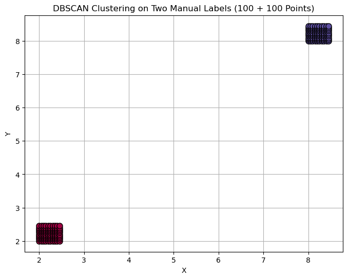

```python
# Unique cluster labels
unique_labels = set(predicted_labels)

# Assign color per cluster
colors = [plt.cm.Spectral(each) for each in np.linspace(0, 1, len(unique_labels))]

plt.figure(figsize=(8, 6))

for k, col in zip(unique_labels, colors):
    if k == -1:
        col = [0, 0, 0, 1]  # Black for noise

    class_member_mask = (predicted_labels == k)
    xy = X[class_member_mask]
    plt.plot(xy[:, 0], xy[:, 1], 'o',
             markerfacecolor=tuple(col),
             markeredgecolor='k', markersize=8)

plt.title("DBSCAN Clustering on Two Manual Labels (100 + 100 Points)")
plt.xlabel("X")
plt.ylabel("Y")
plt.grid(True)
plt.show()
```

# STEP 1: Import required libraries

```python
import numpy as np
import matplotlib.pyplot as plt
from sklearn.datasets import load_iris
from sklearn.preprocessing import StandardScaler
from sklearn.cluster import DBSCAN
from sklearn.decomposition import PCA
```

STEP 2: Load Iris dataset

```python
# Load Iris data
iris = load_iris()
X = iris.data              # Shape: (150, 4) — 4 features
true_labels = iris.target  # Actual labels (0, 1, 2)
```

STEP 3: Standardize the features

```python
# Normalize the feature values
scaler = StandardScaler()
X_scaled = scaler.fit_transform(X)
```

STEP 4: Apply DBSCAN clustering

```python
# Apply DBSCAN
db = DBSCAN(eps=0.6, min_samples=5)  # You can tweak eps
db.fit(X_scaled)

# Get predicted cluster labels
predicted_labels = db.labels_
```

STEP 5: Print clustering summary

```python
# Count clusters and noise
n_clusters = len(set(predicted_labels)) - (1 if -1 in predicted_labels else 0)
n_noise = list(predicted_labels).count(-1)

print(f"Estimated number of clusters: {n_clusters}")
print(f"Estimated number of noise points: {n_noise}")
```

```
Estimated number of clusters: 2
Estimated number of noise points: 26
```

STEP 6: Visualize the result using PCA (2D projection)

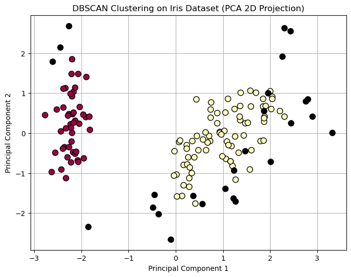

```python
# Reduce dimensionality to 2D for visualization
pca = PCA(n_components=2)
X_pca = pca.fit_transform(X_scaled)

# Plot
unique_labels = set(predicted_labels)
colors = [plt.cm.Spectral(each) for each in np.linspace(0, 1, len(unique_labels))]

plt.figure(figsize=(8, 6))

for k, col in zip(unique_labels, colors):
    if k == -1:
        col = [0, 0, 0, 1]  # Black for noise

    class_member_mask = (predicted_labels == k)
    xy = X_pca[class_member_mask]
    plt.plot(xy[:, 0], xy[:, 1], 'o',
             markerfacecolor=tuple(col),
             markeredgecolor='k', markersize=8)

plt.title("DBSCAN Clustering on Iris Dataset (PCA 2D Projection)")
plt.xlabel("Principal Component 1")
plt.ylabel("Principal Component 2")
plt.grid(True)
plt.show()
```

```python
from sklearn.datasets import load_iris
from sklearn.preprocessing import StandardScaler
from sklearn.cluster import DBSCAN
import numpy as np

# Load and standardize the data
iris = load_iris()
X = iris.data
scaler = StandardScaler()
X_scaled = scaler.fit_transform(X)
```

```python
# Try multiple values of eps and min_samples
eps_values = [0.3, 0.4, 0.5, 0.6, 0.7]
min_samples_values = [3, 4, 5, 6]

print("eps\tmin_samples\tclusters\tnoise_points")
print("-" * 50)

for eps in eps_values:
    for min_samples in min_samples_values:
        db = DBSCAN(eps=eps, min_samples=min_samples)
        db.fit(X_scaled)
        labels = db.labels_
        n_clusters = len(set(labels)) - (1 if -1 in labels else 0)
        n_noise = list(labels).count(-1)
        print(f"{eps:.2f}\t{min_samples}\t\t{n_clusters}\t\t{n_noise}")
```

```
eps	min_samples	clusters	noise_points
--------------------------------------------------
0.30	3		10		84
0.30	4		5		107
0.30	5		3		120
0.30	6		2		129
0.40	3		10		39
0.40	4		5		61
0.40	5		6		66
0.40	6		5		90
0.50	3		7		17
0.50	4		2		33
0.50	5		2		34
0.50	6		4		42
0.60	3		4		9
0.60	4		3		19
0.60	5		2		26
0.60	6		2		29
0.70	3		2		5
0.70	4		2		5
0.70	5		2		6
0.70	6		2		12
```

```python
db = DBSCAN(eps=0.6, min_samples=5)
db.fit(X_scaled)
labels = db.labels_

print("Clusters:", len(set(labels)) - (1 if -1 in labels else 0))
print("Noise points:", list(labels).count(-1))
```

```
Clusters: 2
Noise points: 26
```

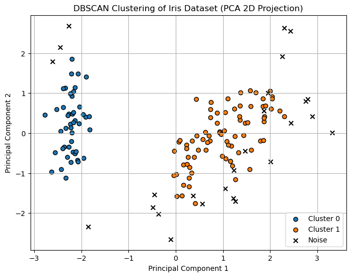

```python
import matplotlib.pyplot as plt
from sklearn.decomposition import PCA

# Assume 'X_scaled' is your scaled Iris data
# and 'predicted_labels' are the cluster labels from DBSCAN

# Step 1: Reduce 4D to 2D with PCA
pca = PCA(n_components=2)
X_pca = pca.fit_transform(X_scaled)

# Step 2: Plot clusters
unique_labels = set(predicted_labels)
colors = plt.cm.tab10.colors  # Get 10 distinct colors

plt.figure(figsize=(8, 6))

for label in unique_labels:
    if label == -1:
        # Noise points in black
        color = 'k'
        marker = 'x'
        label_name = 'Noise'
    else:
        color = colors[label % 10]
        marker = 'o'
        label_name = f'Cluster {label}'

    cluster_points = X_pca[predicted_labels == label]
    plt.scatter(cluster_points[:, 0], cluster_points[:, 1],
                c=[color], marker=marker, label=label_name, edgecolors='k')

plt.title("DBSCAN Clustering of Iris Dataset (PCA 2D Projection)")
plt.xlabel("Principal Component 1")
plt.ylabel("Principal Component 2")
plt.legend()
plt.grid(True)
plt.show()
```

# What you see on this plot:

Each point is a flower sample projected on 2 principal components.

Points colored by their DBSCAN cluster label.

Noise points shown as black x marks.

You can visually check if DBSCAN grouped similar points.

# Dataset - Reason

- Iris dataset
- Clusters overlap and have similar densities; DBSCAN struggles compared to KMeans
- Very high-dimensional text data (without dimensionality reduction)
- Distance measures lose meaning
- Data with very varied cluster densities
- Hard to choose a single eps parameter

# 3 DBSCAN on Two Moons dataset

### Step 1: Generate the Two Moons dataset

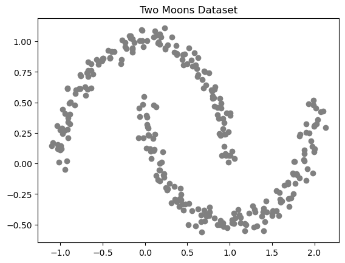

```python
from sklearn.datasets import make_moons
import matplotlib.pyplot as plt

# Create dataset with 300 samples and some noise
X, y_true = make_moons(n_samples=300, noise=0.05, random_state=42)

# Plot raw data
plt.scatter(X[:, 0], X[:, 1], c='gray')
plt.title("Two Moons Dataset")
plt.show()
```

### Import DBSCAN and run clustering with initial parameters

```python
from sklearn.cluster import DBSCAN

# Run DBSCAN with some initial eps and min_samples
db = DBSCAN(eps=0.2, min_samples=5)
db.fit(X)

labels = db.labels_  # Cluster labels (-1 means noise)

print("Number of clusters found:", len(set(labels)) - (1 if -1 in labels else 0))
print("Number of noise points:", list(labels).count(-1))
```

```
Number of clusters found: 2
Number of noise points: 0
```

### Step 3: Visualize the clusters found by DBSCAN

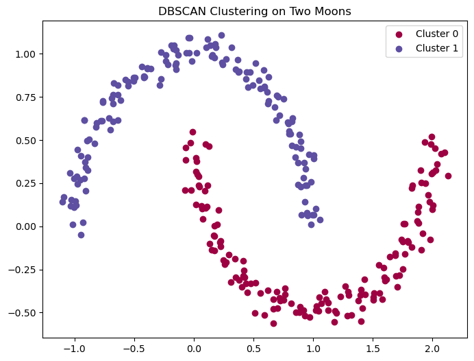

```python
import numpy as np

unique_labels = set(labels)
colors = [plt.cm.Spectral(each) for each in np.linspace(0, 1, len(unique_labels))]

plt.figure(figsize=(8,6))

for k, col in zip(unique_labels, colors):
    if k == -1:
        # Noise points are black
        col = [0, 0, 0, 1]

    class_member_mask = (labels == k)
    xy = X[class_member_mask]
    plt.scatter(xy[:, 0], xy[:, 1], c=[col], label=f'Cluster {k}' if k != -1 else 'Noise')

plt.title("DBSCAN Clustering on Two Moons")
plt.legend()
plt.show()
```

## Step 4: Tune eps and min_samples to find better clusters (grid search)

```python
import numpy as np

eps_values = np.arange(0.1, 0.5, 0.05)
min_samples_values = range(3, 8)

results = []

for eps in eps_values:
    for min_samples in min_samples_values:
        db = DBSCAN(eps=eps, min_samples=min_samples).fit(X)
        labels = db.labels_
        n_clusters = len(set(labels)) - (1 if -1 in labels else 0)
        n_noise = list(labels).count(-1)
        results.append((eps, min_samples, n_clusters, n_noise))

# Print results in a table form
print("eps\tmin_samples\tclusters\tnoise")
for res in results:
    print(f"{res[0]:.2f}\t{res[1]}\t\t{res[2]}\t\t{res[3]}")
```

```
eps	min_samples	clusters	noise
0.10	3		5		7
0.10	4		5		9
0.10	5		7		13
0.10	6		12		22
0.10	7		16		40
0.15	3		2		0
0.15	4		2		0
0.15	5		2		0
0.15	6		2		0
0.15	7		2		0
0.20	3		2		0
0.20	4		2		0
0.20	5		2		0
0.20	6		2		0
0.20	7		2		0
0.25	3		2		0
0.25	4		2		0
0.25	5		2		0
0.25	6		2		0
0.25	7		2		0
0.30	3		2		0
0.30	4		2		0
0.30	5		2		0
0.30	6		2		0
0.30	7		2		0
0.35	3		2		0
0.35	4		2		0
0.35	5		2		0
0.35	6		2		0
0.35	7		2		0
0.40	3		1		0
0.40	4		1		0
0.40	5		1		0
0.40	6		1		0
0.40	7		1		0
0.45	3		1		0
0.45	4		1		0
0.45	5		1		0
0.45	6		1		0
0.45	7		1		0
```

### Step 5: Visualize clusters for best parameters (e.g. eps=0.2, min_samples=5)

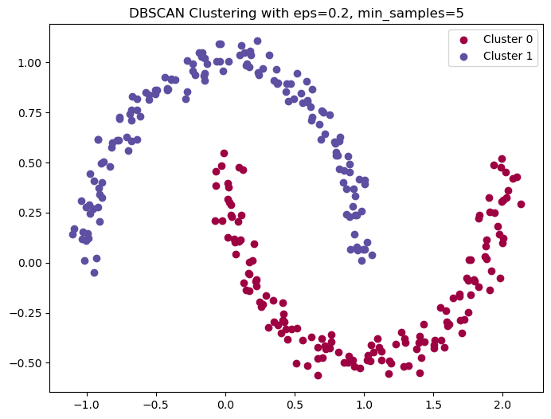

```python
best_eps = 0.2
best_min_samples = 5

db = DBSCAN(eps=best_eps, min_samples=best_min_samples).fit(X)
labels = db.labels_

plt.figure(figsize=(8,6))
unique_labels = set(labels)
colors = [plt.cm.Spectral(each) for each in np.linspace(0, 1, len(unique_labels))]

for k, col in zip(unique_labels, colors):
    if k == -1:
        col = [0, 0, 0, 1]  # Black for noise
    class_member_mask = (labels == k)
    xy = X[class_member_mask]
    plt.scatter(xy[:, 0], xy[:, 1], c=[col], label=f'Cluster {k}' if k != -1 else 'Noise')

plt.title(f"DBSCAN Clustering with eps={best_eps}, min_samples={best_min_samples}")
plt.legend()
plt.show()
```

Generated synthetic 2D data (Two Moons).

Applied DBSCAN with initial parameters.

Visualized clusters and noise.

Tuned parameters via grid search.

Visualized best clustering result.

# min_samples-3

Based on "dimensions + 1" rule (2D space → 2+1=3)

# eps-0.3

Trial value based on experience; small enough to prevent over-clustering